# ML CASE STUDY

Name: Ankush Sharma  
Roll no.: AM.SC.P2AML23003  
Branch: MTech CSE (AIML)

# Problem Definition

**Background:**  
what exactly makes an airline the best airline in the world?This dataset contains an airline passenger satisfaction survey. What factors are highly correlated to a satisfied (or dissatisfied) passenger? To predict passenger satisfaction.

**The problem questions:**  
a. How can airlines know which factors are most important for/the strongest contributors to customer satisfaction?  
b. Which factors contributing to satisfaction correlate with one another?  
c. Are a random set of customers more likely to be satisfied or neutral/dissatisfied with an airline experience?  
**Objective:**  
Clean, fit a model to predict, and visualize & interpret the passenger satisfaction data to find the relationships between category ratings and overall satisfaction of the passenger, as well as evaluate the results.

# Dataset

**Gender:** Unveil the diversity of passengers with two distinct values, offering insights into the gender distribution and its potential influence on satisfaction.

**Customer Type:** Distinguish between regular customers and those with a different status. Understand how service preferences might vary between these customer types.

**Age:** Embark on a journey through age demographics with 75 unique values. Discover the range of ages among passengers, contributing to a nuanced understanding of their preferences. Generation feature was created from age range.

**Type of Travel:** Uncover the purpose behind each journey—business or leisure. The Type of Travel column reveals the diverse motivations that shape passenger experiences.

**Class:** Explore the array of travel classes with three unique values. Delve into the world of passenger preferences across different service levels.

**Flight Distance:** Navigate through 3821 unique values, representing a comprehensive range of distances traveled. Gain insights into satisfaction trends across varying journey lengths.

**Service Ratings:** Encounter multiple columns assessing different in-flight services, each offering six unique values. These ratings paint a detailed picture of passenger experiences, providing a holistic view of service quality.

**Departure and Arrival Delays:** Experience the ebb and flow of time with Departure Delay in Minutes' and 'Arrival Delay in Minutes. With a range of 464 to 472 unique values, understand the impact of delays on passenger satisfaction.

**Satisfaction:** Unveil the essence of the dataset—the Satisfaction column. With two unique values, this column serves as the bedrock for predictive modeling, unlocking the secrets behind passenger contentment or discontent.

**Target Variable** The primary target for analysis is the satisfaction column in the dataset.

```python
# importing libraries and dataset
import pandas as pd
import numpy as np
df = pd.read_csv("airline_passenger_satisfaction.csv")
```

```python
# First 5 rows
df.head()
```

|  | ID | Gender | Age | Customer Type | Type of Travel | Class | Flight Distance | Departure Delay | Arrival Delay | Departure and Arrival Time Convenience | ... | On-board Service | Seat Comfort | Leg Room Service | Cleanliness | Food and Drink | In-flight Service | In-flight Wifi Service | In-flight Entertainment | Baggage Handling | Satisfaction |
| --- | --- | --- | --- | --- | --- | --- | --- | --- | --- | --- | --- | --- | --- | --- | --- | --- | --- | --- | --- | --- | --- |
| 0 | 1 | Male | 48 | First-time | Business | Business | 821 | 2 | 5.0 | 3 | ... | 3 | 5 | 2 | 5 | 5 | 5 | 3 | 5 | 5 | Neutral or Dissatisfied |
| 1 | 2 | Female | 35 | Returning | Business | Business | 821 | 26 | 39.0 | 2 | ... | 5 | 4 | 5 | 5 | 3 | 5 | 2 | 5 | 5 | Satisfied |
| 2 | 3 | Male | 41 | Returning | Business | Business | 853 | 0 | 0.0 | 4 | ... | 3 | 5 | 3 | 5 | 5 | 3 | 4 | 3 | 3 | Satisfied |
| 3 | 4 | Male | 50 | Returning | Business | Business | 1905 | 0 | 0.0 | 2 | ... | 5 | 5 | 5 | 4 | 4 | 5 | 2 | 5 | 5 | Satisfied |
| 4 | 5 | Female | 49 | Returning | Business | Business | 3470 | 0 | 1.0 | 3 | ... | 3 | 4 | 4 | 5 | 4 | 3 | 3 | 3 | 3 | Satisfied |

5 rows × 24 columns

# EDA (Exploratory Data Analysis)

## Data summary

```python
df.shape
```

```
(129880, 24)
```

There are 24 categories and 129880 entries

```python
# Data tyype information of columns
df.info()
```

```
<class 'pandas.core.frame.DataFrame'>
RangeIndex: 129880 entries, 0 to 129879
Data columns (total 24 columns):
 #   Column                                  Non-Null Count   Dtype
---  ------                                  --------------   -----
 0   ID                                      129880 non-null  int64
 1   Gender                                  129880 non-null  object
 2   Age                                     129880 non-null  int64
 3   Customer Type                           129880 non-null  object
 4   Type of Travel                          129880 non-null  object
 5   Class                                   129880 non-null  object
 6   Flight Distance                         129880 non-null  int64
 7   Departure Delay                         129880 non-null  int64
 8   Arrival Delay                           129487 non-null  float64
 9   Departure and Arrival Time Convenience  129880 non-null  int64
```

[output cut: 16 more lines]

**There are a few things to notice in terms of data cleaning:**

a. Number of Numerical features = 19  
b. Number of Categorical features = 5  
c. The first column is unnecessary, as it is not relevant to the analysis

```python
# Find missing values
df.isnull().sum()
```

```
ID                                          0
Gender                                      0
Age                                         0
Customer Type                               0
Type of Travel                              0
Class                                       0
Flight Distance                             0
Departure Delay                             0
Arrival Delay                             393
Departure and Arrival Time Convenience      0
Ease of Online Booking                      0
Check-in Service                            0
Online Boarding                             0
Gate Location                               0
On-board Service                            0
Seat Comfort                                0
Leg Room Service                            0
Cleanliness                                 0
Food and Drink                              0
In-flight Service                           0
In-flight Wifi Service                      0
In-flight Entertainment                     0
Baggage Handling                            0
Satisfaction                                0
dtype: int64
```

The column "Arrival Delay" has 393 missing values  
Since the missing values are very few compared to the total entries, we will replace them with 0.

```python
# dataset description
df.describe()
```

|  | ID | Age | Flight Distance | Departure Delay | Arrival Delay | Departure and Arrival Time Convenience | Ease of Online Booking | Check-in Service | Online Boarding | Gate Location | On-board Service | Seat Comfort | Leg Room Service | Cleanliness | Food and Drink | In-flight Service | In-flight Wifi Service | In-flight Entertainment | Baggage Handling |
| --- | --- | --- | --- | --- | --- | --- | --- | --- | --- | --- | --- | --- | --- | --- | --- | --- | --- | --- | --- |
| count | 129880.000000 | 129880.000000 | 129880.000000 | 129880.000000 | 129487.000000 | 129880.000000 | 129880.000000 | 129880.000000 | 129880.000000 | 129880.000000 | 129880.000000 | 129880.000000 | 129880.000000 | 129880.000000 | 129880.000000 | 129880.000000 | 129880.000000 | 129880.000000 | 129880.000000 |
| mean | 64940.500000 | 39.427957 | 1190.316392 | 14.713713 | 15.091129 | 3.057599 | 2.756876 | 3.306267 | 3.252633 | 2.976925 | 3.383023 | 3.441361 | 3.350878 | 3.286326 | 3.204774 | 3.642193 | 2.728696 | 3.358077 | 3.632114 |
| std | 37493.270818 | 15.119360 | 997.452477 | 38.071126 | 38.465650 | 1.526741 | 1.401740 | 1.266185 | 1.350719 | 1.278520 | 1.287099 | 1.319289 | 1.316252 | 1.313682 | 1.329933 | 1.176669 | 1.329340 | 1.334049 | 1.180025 |
| min | 1.000000 | 7.000000 | 31.000000 | 0.000000 | 0.000000 | 0.000000 | 0.000000 | 0.000000 | 0.000000 | 0.000000 | 0.000000 | 0.000000 | 0.000000 | 0.000000 | 0.000000 | 0.000000 | 0.000000 | 0.000000 | 1.000000 |
| 25% | 32470.750000 | 27.000000 | 414.000000 | 0.000000 | 0.000000 | 2.000000 | 2.000000 | 3.000000 | 2.000000 | 2.000000 | 2.000000 | 2.000000 | 2.000000 | 2.000000 | 2.000000 | 3.000000 | 2.000000 | 2.000000 | 3.000000 |
| 50% | 64940.500000 | 40.000000 | 844.000000 | 0.000000 | 0.000000 | 3.000000 | 3.000000 | 3.000000 | 3.000000 | 3.000000 | 4.000000 | 4.000000 | 4.000000 | 3.000000 | 3.000000 | 4.000000 | 3.000000 | 4.000000 | 4.000000 |
| 75% | 97410.250000 | 51.000000 | 1744.000000 | 12.000000 | 13.000000 | 4.000000 | 4.000000 | 4.000000 | 4.000000 | 4.000000 | 4.000000 | 5.000000 | 4.000000 | 4.000000 | 4.000000 | 5.000000 | 4.000000 | 4.000000 | 5.000000 |
| max | 129880.000000 | 85.000000 | 4983.000000 | 1592.000000 | 1584.000000 | 5.000000 | 5.000000 | 5.000000 | 5.000000 | 5.000000 | 5.000000 | 5.000000 | 5.000000 | 5.000000 | 5.000000 | 5.000000 | 5.000000 | 5.000000 | 5.000000 |

The mean, standard deviation, min and max, as well as median and quartile values are given above for each quantitative attribute.

```python
# Full data summary before data preprocessing

print("\t\t\tDataset Statistics")
print("Number of columns:-",len(df.columns))
print("Number of observations:-",df.shape[0])
print("Missing Values:-",df.isna().sum().sum())
print("Missing Values %:-",round(df.isna().sum().sum()/df.shape[0]*100,3))
print("Duplicate rows:-",df[df.duplicated(keep="first")].shape[0])
print("Duplicate rows%:-",round(df[df.duplicated(keep="first")].shape[0]/df.shape[0]*100,3))
print("Variable types:-")
a=pd.crosstab(df.dtypes,columns="Count")
for i in pd.crosstab(df.dtypes,columns="Count").index:
    print("\t",str(i).split()[0],a.loc[i][0])
```

```
			Dataset Statistics
Number of columns:- 24
Number of observations:- 129880
Missing Values:- 393
Missing Values %:- 0.303
Duplicate rows:- 0
Duplicate rows%:- 0.0
Variable types:-
	 int64 18
	 float64 1
	 object 5
```

```python
# Fill missing values
df.fillna(0,inplace=True)
```

## Data visualization

In this section, we will represent the data through use of common graphics, such as plots,charts and heatmaps. These visual graphs will allow us to get a better understanding of the dataset and find correlations between its features.

Libraries used for data visualization:

**Matplotlib:** is a powerful tool for creating visualizations in Python, providing many options for different types of plots. As users become more familiar with Matplotlib, they can use its various plot styles and customization options to make appealing and informative graphics for understanding and presenting data.  
**Seaborn:** is a Python data visualization library based on matplotlib. It provides a high-level interface for drawing attractive and informative statistical graphics.

```python
# importing libraries for EDA
import seaborn as sns
import matplotlib.pyplot as plt
```

```python
# Create the DataFrame description
print('Description of the Categorical Dataset:')
print("=" * 40)
categorical_description = df.describe(include=['object', 'bool']).T
categorical_description
```

```
Description of the Categorical Dataset:
========================================
```

|  | count | unique | top | freq |
| --- | --- | --- | --- | --- |
| Gender | 129880 | 2 | Female | 65899 |
| Customer Type | 129880 | 2 | Returning | 106100 |
| Type of Travel | 129880 | 2 | Business | 89693 |
| Class | 129880 | 3 | Business | 62160 |
| Satisfaction | 129880 | 2 | Neutral or Dissatisfied | 73452 |

```python
def draw_categorical_plot(data, figsize=(8, 6), colors=None):

    if not isinstance(data, pd.Series):
        raise ValueError("Input data should be a categorical data.")

    # Count the occurrences of each category in the data
    counts = data.value_counts()

    # Create a figure and axes
    fig, ax = plt.subplots(figsize=figsize)

    # If there are less than 6 unique observations, draw a pie chart
    if len(counts) <= 5:
        counts.plot(kind='pie', autopct='%1.1f%%', colors=colors, ax=ax)
        ax.set_title("Pie Chart of " + data.name)
        ax.set_ylabel("")  # This is to remove the column name from the side of the pie chart
    else:
        # Otherwise, draw a bar chart
        sns.barplot(x=counts.index, y=counts.values, palette=colors, ax=ax)
        ax.set_title("Bar Chart of " + data.name)
        ax.set_ylabel("Count")

    plt.tight_layout()
    plt.show()  # Display the plot
```

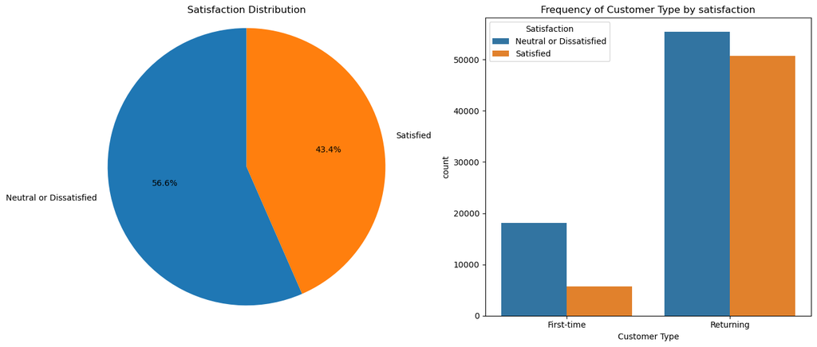

```python
# Create subplots in a 1x2 grid
fig, axes = plt.subplots(1, 2, figsize=(14, 6))

# Plot 1: satisfaction Distribution (Pie Chart)
satify_status_counts = df['Satisfaction'].value_counts()
labels = satify_status_counts.index
sizes = satify_status_counts.values

axes[0].pie(sizes, labels=labels, autopct='%1.1f%%', startangle=90)
axes[0].set_title('Satisfaction Distribution')
axes[0].axis('equal')  # Equal aspect ratio ensures that the pie chart is circular

# Plot 2: Frequency of Customer Type by satisfaction (Countplot)
sns.countplot(data=df, x="Customer Type", hue="Satisfaction", ax=axes[1])
axes[1].set_title('Frequency of Customer Type by satisfaction')

# Display the plots in a tight layout
plt.tight_layout()
plt.show()
```

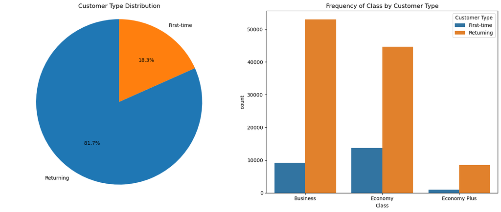

```python
# Create subplots in a 1x2 grid
fig, axes = plt.subplots(1, 2, figsize=(14, 6))

# Plot 1: Customer Type Distribution (Pie Chart)
cost_status_counts = df['Customer Type'].value_counts()
labels = cost_status_counts.index
sizes = cost_status_counts.values

axes[0].pie(sizes, labels=labels, autopct='%1.1f%%', startangle=90)
axes[0].set_title('Customer Type Distribution')
axes[0].axis('equal')  # Equal aspect ratio ensures that the pie chart is circular

# Plot 2: Frequency of Class by Customer Type (Countplot)
sns.countplot(data=df, x="Class", hue="Customer Type", ax=axes[1])
axes[1].set_title('Frequency of Class by Customer Type')

# Display the plots in a tight layout
plt.tight_layout()
plt.show()
```

81.7% of the passengers in the survey were returning customers, the rest being first-timers with the airline. We can see that returning customers for all the three classes i.e. Business, Economy, and economy plus has much more returning customers that first timers. Notably, Economy Plus has the lowest count, therefore, there is an unequal distribution in the class of customers in the dataset, however, this may also be because Economy Plus is generally flown the least.

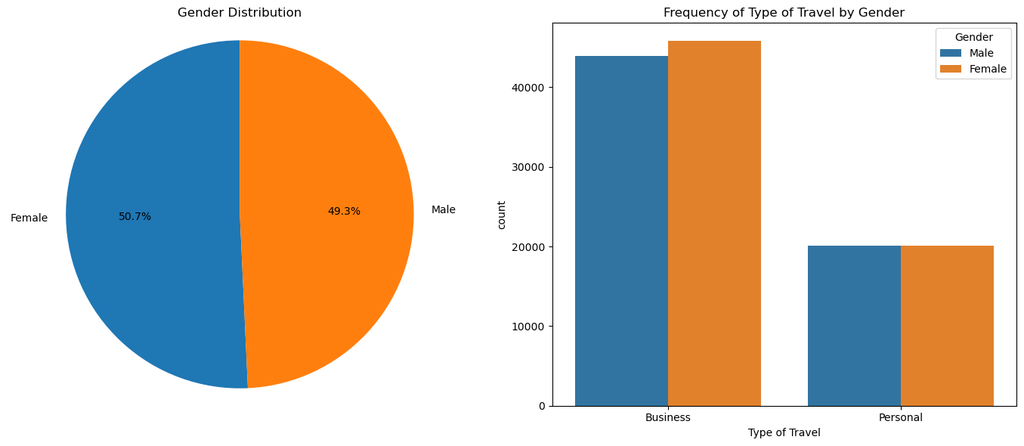

```python
# Create subplots in a 1x2 grid
fig, axes = plt.subplots(1, 2, figsize=(14, 6))

# Plot 1: Gender Distribution (Pie Chart)
gender_status_counts = df['Gender'].value_counts()
labels = gender_status_counts.index
sizes = gender_status_counts.values

axes[0].pie(sizes, labels=labels, autopct='%1.1f%%', startangle=90)
axes[0].set_title('Gender Distribution')
axes[0].axis('equal')  # Equal aspect ratio ensures that the pie chart is circular

# Plot 2: Frequency of Type of Travel by Gender (Countplot)
sns.countplot(data=df, x="Type of Travel", hue="Gender", ax=axes[1])
axes[1].set_title('Frequency of Type of Travel by Gender')

# Display the plots in a tight layout
plt.tight_layout()
plt.show()
```

The number of females is slightly higher than the number of males. From the bar graph that indicates type of travel i.e. business and personal of males and females in a flight. We can conclude that number of females that travel for business are slightly more than males in airlines. While number of males and females in the flight are same if they travel for personal reasons.

**Visulization of varios features using pie-chart, barplot, histogram to record interpretations with varyying values**

```python
#Making a new dataframe with only the columns that have passenger ratings and Satisfaction.
Ratings_df=df.iloc[:,9:df.shape[1]]
Ratings_df.head()
```

|  | Departure and Arrival Time Convenience | Ease of Online Booking | Check-in Service | Online Boarding | Gate Location | On-board Service | Seat Comfort | Leg Room Service | Cleanliness | Food and Drink | In-flight Service | In-flight Wifi Service | In-flight Entertainment | Baggage Handling | Satisfaction |
| --- | --- | --- | --- | --- | --- | --- | --- | --- | --- | --- | --- | --- | --- | --- | --- |
| 0 | 3 | 3 | 4 | 3 | 3 | 3 | 5 | 2 | 5 | 5 | 5 | 3 | 5 | 5 | Neutral or Dissatisfied |
| 1 | 2 | 2 | 3 | 5 | 2 | 5 | 4 | 5 | 5 | 3 | 5 | 2 | 5 | 5 | Satisfied |
| 2 | 4 | 4 | 4 | 5 | 4 | 3 | 5 | 3 | 5 | 5 | 3 | 4 | 3 | 3 | Satisfied |
| 3 | 2 | 2 | 3 | 4 | 2 | 5 | 5 | 5 | 4 | 4 | 5 | 2 | 5 | 5 | Satisfied |
| 4 | 3 | 3 | 3 | 5 | 3 | 3 | 4 | 4 | 5 | 4 | 3 | 3 | 3 | 3 | Satisfied |

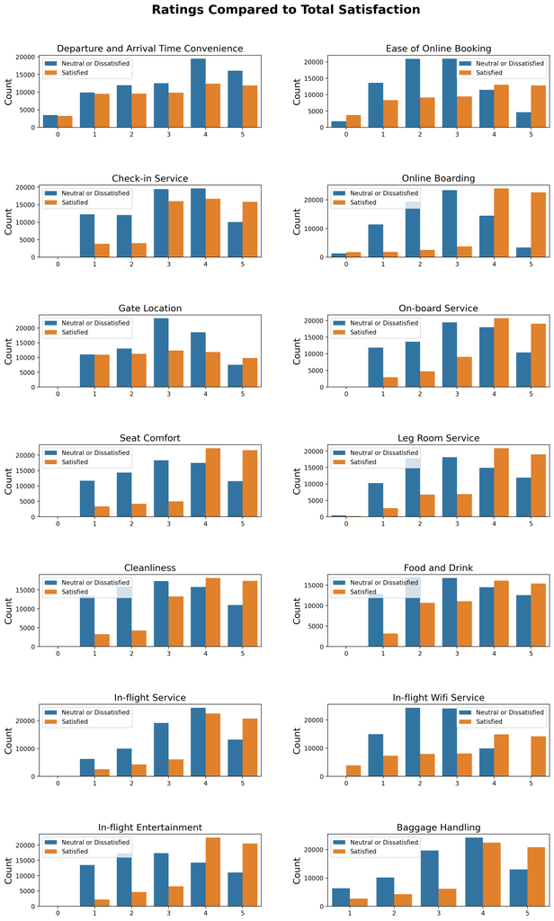

```python
fig = plt.figure(figsize=(15,29),dpi=200)
for i,column in enumerate(Ratings_df):
    if i!=14:
        plt.subplot(8,2,i+1)
        ax=sns.countplot(x=column,hue='Satisfaction',data=Ratings_df)
        ax.set_title(column,size=15)
        ax.legend(fontsize='10')
        plt.xlabel('')
        plt.ylabel('Count',size=15)

plt.subplots_adjust(hspace = 0.8, wspace=0.3)
fig.suptitle("Ratings Compared to Total Satisfaction",size=20,fontweight='bold',y=0.92)
plt.show()
```

**Analysis of above count plot**

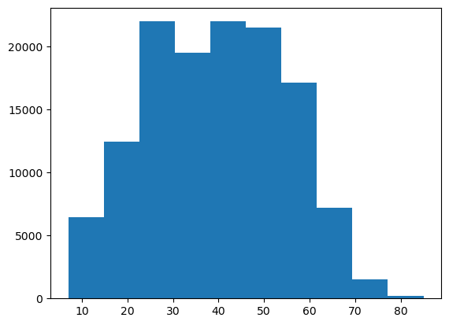

```python
plt.hist(df['Age'])
```

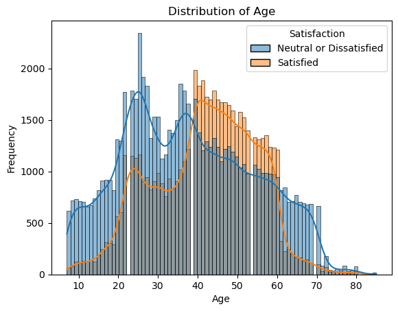

```python
sns.histplot(data=df, x='Age', kde=True, hue='Satisfaction')

plt.title(f'Distribution of Age')
plt.ylabel('Frequency')
plt.xlabel('Age')
plt.show()
```

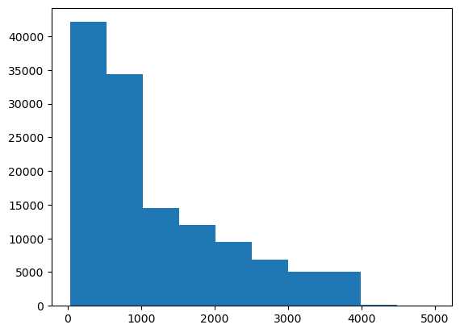

```python
plt.hist(df['Flight Distance'])
```

[output not shown]

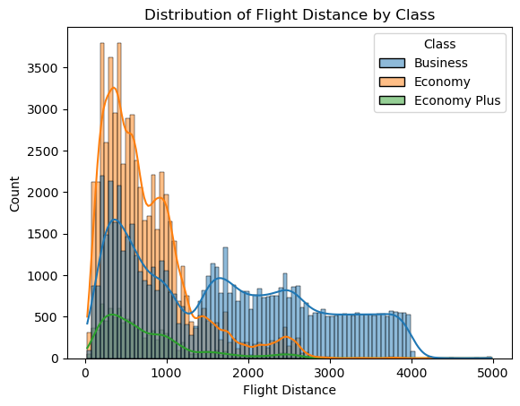

```python
sns.histplot(x='Flight Distance',data=df,hue='Class',kde=True).set(title='Distribution of Flight Distance by Class')
```

We can also see that as flight distance increases, more people take Business class than Economy or Economy Plus. However, for short distances, particularly those under 1000 miles, Economy class is by far the most popular choice. Economy Plus is consistently the least popular choice among the flight classes.

[output not shown]

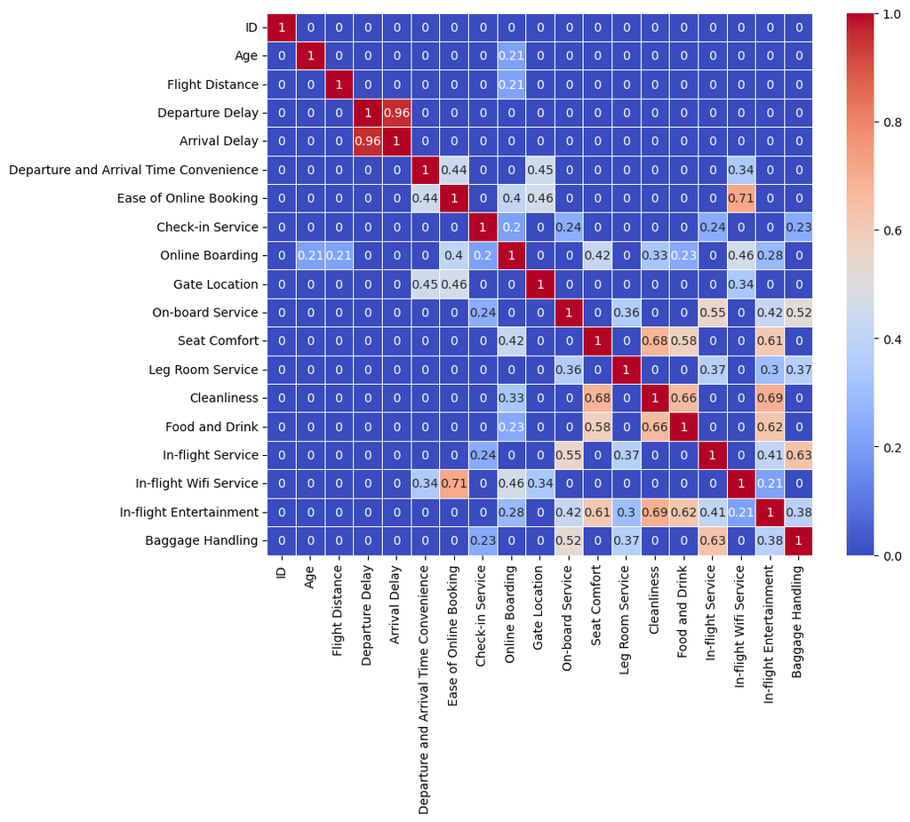

```python
corr = df.corr()
high_corr = corr[abs(corr) > 0.2].fillna(0)
plt.figure(figsize=(10, 8))
sns.heatmap(high_corr, cmap='coolwarm', annot=True, linewidths=.5)
plt.show()
```

### Noteable observations:

Overall, there are not many categories that seem to have a significantly strong relationship relative to others with another category, as well as with total satisfaction. It may be beneficial to group some of the specific categories together into slightly broader categories and compute their relationship to satisfaction in a different manner, as factors put together may have a larger impact on satisfaction.

### Summary of data visualization

1. Depicts the data across gender distribution is approimately balanced data set. 50.7% of female and 49.3 % of male data involved for the analysis.  
2. Overall we have more loyal customer data in this survey.  
3. Look like more people are travelling in business class compared to economic class.  
4. All kind of age people ae participating in the survey but people of age near 25 and 40 years are travelling more.

# DATA PRE-PROCESSING

In order to streamline the analysis, I decided to create broader categories out of the ones that currently exist in the dataset:  
1. Time and Location: 'Departure and arrival time convenient," "Gate location"  
2. Inflight Entertainment: 'Inflight wifi service,' 'inflight entertainment'  
3. Online services: 'Ease of Online booking', 'Online boarding'  
4. Food and drink  
5. Comfort: 'Leg room service', 'seat comfort'  
6. Cleanliness  
7. Service: 'Boarding service', 'Baggage handling', 'Checkin service', 'Inflight service'

These new categories will help make analysis simpler, under the assumption that subcategories in each broader categories are related to one another in terms of their performance. For example, good leg room is expected to relate to good seat comfort, and ease of online booking would also relate to ease of online check-in.

**Methodology for combining colunms:** The average rating within each of these categories will be calculated for each customer, and then each category will be compared with another in order to see which one has the greatest effect on overall satisfaction and average rating.  
**Dataset Splitting:**  
For model development, the dataset was split into training (60%), testing (20%), and validation (20%) sets.  
**Label Encoder:**  
Label Encoding is a technique that is used to convert categorical columns into numerical ones so that they can be fitted by machine learning models which only take numerical data. It is an important pre-processing step in a machine-learning project.  
**Standardization:**  
A standard scaler was applied to standardize the data, bringing features to a common scale. This preprocessing step is essential for optimizing machine learning algorithms and ensuring fair contributions from each feature in subsequent analyses.

```python
df = pd.read_csv("airline_passenger_satisfaction.csv")

#Adding columns for the average ratings of each of the new categories
df['Time and Location']=(df['Departure and Arrival Time Convenience'] + df['Gate Location'])/2
df['Inflight Entertainment']= (df['In-flight Wifi Service'] + df['In-flight Entertainment'])/2
df['Online Services'] = (df['Ease of Online Booking'] + df['Online Boarding'])/2
df['Comfort'] = (df['Leg Room Service'] + df['Seat Comfort'])/2
df['Service']=(df['On-board Service'] + df['Check-in Service']+df['Baggage Handling']+df['In-flight Service'])/4

# Fill null values as 0
df.fillna(0,inplace=True)

df.head()
```

|  | ID | Gender | Age | Customer Type | Type of Travel | Class | Flight Distance | Departure Delay | Arrival Delay | Departure and Arrival Time Convenience | ... | In-flight Service | In-flight Wifi Service | In-flight Entertainment | Baggage Handling | Satisfaction | Time and Location | Inflight Entertainment | Online Services | Comfort | Service |
| --- | --- | --- | --- | --- | --- | --- | --- | --- | --- | --- | --- | --- | --- | --- | --- | --- | --- | --- | --- | --- | --- |
| 0 | 1 | Male | 48 | First-time | Business | Business | 821 | 2 | 5.0 | 3 | ... | 5 | 3 | 5 | 5 | Neutral or Dissatisfied | 3.0 | 4.0 | 3.0 | 3.5 | 4.25 |
| 1 | 2 | Female | 35 | Returning | Business | Business | 821 | 26 | 39.0 | 2 | ... | 5 | 2 | 5 | 5 | Satisfied | 2.0 | 3.5 | 3.5 | 4.5 | 4.50 |
| 2 | 3 | Male | 41 | Returning | Business | Business | 853 | 0 | 0.0 | 4 | ... | 3 | 4 | 3 | 3 | Satisfied | 4.0 | 3.5 | 4.5 | 4.0 | 3.25 |
| 3 | 4 | Male | 50 | Returning | Business | Business | 1905 | 0 | 0.0 | 2 | ... | 5 | 2 | 5 | 5 | Satisfied | 2.0 | 3.5 | 3.0 | 5.0 | 4.50 |
| 4 | 5 | Female | 49 | Returning | Business | Business | 3470 | 0 | 1.0 | 3 | ... | 3 | 3 | 3 | 3 | Satisfied | 3.0 | 3.0 | 4.0 | 4.0 | 3.00 |

5 rows × 29 columns

```python
# Remove unimportant columns and id column
ids = df['ID']

unimportant_cols = ['ID', 'Departure and Arrival Time Convenience', 'Gate Location', 'In-flight Entertainment',
                    'In-flight Wifi Service', 'Online Boarding', 'Ease of Online Booking', 'Seat Comfort',
                    'Leg Room Service', 'On-board Service', 'Check-in Service', 'Baggage Handling', 'In-flight Service'
                   ]
df = df.drop(unimportant_cols, axis=1)
df.head()
```

|  | Gender | Age | Customer Type | Type of Travel | Class | Flight Distance | Departure Delay | Arrival Delay | Cleanliness | Food and Drink | Satisfaction | Time and Location | Inflight Entertainment | Online Services | Comfort | Service |
| --- | --- | --- | --- | --- | --- | --- | --- | --- | --- | --- | --- | --- | --- | --- | --- | --- |
| 0 | Male | 48 | First-time | Business | Business | 821 | 2 | 5.0 | 5 | 5 | Neutral or Dissatisfied | 3.0 | 4.0 | 3.0 | 3.5 | 4.25 |
| 1 | Female | 35 | Returning | Business | Business | 821 | 26 | 39.0 | 5 | 3 | Satisfied | 2.0 | 3.5 | 3.5 | 4.5 | 4.50 |
| 2 | Male | 41 | Returning | Business | Business | 853 | 0 | 0.0 | 5 | 5 | Satisfied | 4.0 | 3.5 | 4.5 | 4.0 | 3.25 |
| 3 | Male | 50 | Returning | Business | Business | 1905 | 0 | 0.0 | 4 | 4 | Satisfied | 2.0 | 3.5 | 3.0 | 5.0 | 4.50 |
| 4 | Female | 49 | Returning | Business | Business | 3470 | 0 | 1.0 | 5 | 4 | Satisfied | 3.0 | 3.0 | 4.0 | 4.0 | 3.00 |

```python
#Importing libraries for preprocessing
from sklearn.preprocessing import LabelEncoder

le = LabelEncoder()
df['Gender'] = le.fit_transform(df['Gender'])
df['Customer Type'] = le.fit_transform(df['Customer Type'])
df['Age'] = le.fit_transform(df['Age'])
df['Type of Travel'] = le.fit_transform(df['Type of Travel'])
df['Class'] = le.fit_transform(df['Class'])
df['Satisfaction'] = le.fit_transform(df['Satisfaction'])
```

```python
df.head()
```

|  | Gender | Age | Customer Type | Type of Travel | Class | Flight Distance | Departure Delay | Arrival Delay | Cleanliness | Food and Drink | Satisfaction | Time and Location | Inflight Entertainment | Online Services | Comfort | Service |
| --- | --- | --- | --- | --- | --- | --- | --- | --- | --- | --- | --- | --- | --- | --- | --- | --- |
| 0 | 1 | 41 | 0 | 0 | 0 | 821 | 2 | 5.0 | 5 | 5 | 0 | 3.0 | 4.0 | 3.0 | 3.5 | 4.25 |
| 1 | 0 | 28 | 1 | 0 | 0 | 821 | 26 | 39.0 | 5 | 3 | 1 | 2.0 | 3.5 | 3.5 | 4.5 | 4.50 |
| 2 | 1 | 34 | 1 | 0 | 0 | 853 | 0 | 0.0 | 5 | 5 | 1 | 4.0 | 3.5 | 4.5 | 4.0 | 3.25 |
| 3 | 1 | 43 | 1 | 0 | 0 | 1905 | 0 | 0.0 | 4 | 4 | 1 | 2.0 | 3.5 | 3.0 | 5.0 | 4.50 |
| 4 | 0 | 42 | 1 | 0 | 0 | 3470 | 0 | 1.0 | 5 | 4 | 1 | 3.0 | 3.0 | 4.0 | 4.0 | 3.00 |

```python
from sklearn.model_selection import train_test_split

# Separate features (X) and target variable (y)
X = df.drop("Satisfaction", axis=1)
y = df['Satisfaction']

# Splitting into training and temp sets first
X_train, X_temp, y_train, y_temp = train_test_split(X, y, test_size=0.4, random_state=1)

# Splitting the temp set into testing and validation sets
X_test, X_val, y_test, y_val = train_test_split(X_temp, y_temp, test_size=0.5, random_state=1)
```

```python
from sklearn.preprocessing import StandardScaler

# Apply StandardScaler to features
sc = StandardScaler()
X_train = sc.fit_transform(X_train)
X_test = sc.transform(X_test)
X_val = sc.transform(X_val)
```

```python
# Full data summary after data preprocessing

print("\t\t\tDataset Statistics after preprocession")
print("Number of columns:-",len(df.columns))
print("Number of observations:-",df.shape[0])
print("Missing Values:-",df.isna().sum().sum())
print("Missing Values %:-",round(df.isna().sum().sum()/df.shape[0]*100,3))
print("Duplicate rows:-",df[df.duplicated(keep="first")].shape[0])
print("Duplicate rows%:-",round(df[df.duplicated(keep="first")].shape[0]/df.shape[0]*100,3))
print("Variable types:-")
a=pd.crosstab(df.dtypes,columns="Count")
for i in pd.crosstab(df.dtypes,columns="Count").index:
    print("\t",str(i).split()[0],a.loc[i][0])
```

```
			Dataset Statistics after preprocession
Number of columns:- 16
Number of observations:- 129880
Missing Values:- 0
Missing Values %:- 0.0
Duplicate rows:- 2
Duplicate rows%:- 0.002
Variable types:-
	 int32 5
	 int64 5
	 float64 6
```

# MODEL BUILDING USING SUPERVISED LEARNING ALGORITHMS

### Packages used

**sklearn:** Scikit-learn (Sklearn) is the most useful and robust library for machine learning in Python. It provides a selection of efficient tools for machine learning and statistical modeling including classification, regression, clustering and dimensionality reduction via a consistence interface in Python. This library, which is largely written in Python, is built upon NumPy, SciPy and Matplotlib.

### Supervised Learning Algorithms

**Definition:** Supervised learning is an approach to creating artificial intelligence ( AI) where a computer algorithm is trained on input data that has been labeled for a particular output.  
**Logistics Regression**

1. Logistic regression is a supervised machine learning algorithm mainly used for binary classification where we use a logistic function, also known as a sigmoid function that takes input as independent variables and produces a probability value between 0 and 1.
2. Utilizing BayesianCV
3. Best Parameters: C: 0.0306, Fit Intercept: True, Penalty: L1, Solver: Liblinear

**Decision Tree Classifier**

1. A decision tree is one of the most powerful tools of supervised learning algorithms used for both classification and regression tasks. It builds a flowchart-like tree structure where each internal node denotes a test on an attribute, each branch represents an outcome of the test, and each leaf node (terminal node) holds a class label.
2. Utilizing BayesianCV
3. Best Hyperparameters: Criterion: Entropy, Max Depth: 15, Min Samples Leaf: 1, Min Samples Split: 10

**Random Forest Classifier**

1. Random forest is a supervised machine learning algorithm that uses a number of decision trees to perform classification or regression tasks. It creates a set of decision trees from randomly selected subsets of the training set and takes the average of their predictions. Random forest reduces the overfitting of the dataset and improves the accuracy of the results

```python
# LOGISTIC REGRESSION
from sklearn.linear_model import LogisticRegression
lr = LogisticRegression(C=0.030571559019667797, fit_intercept=True, penalty='l1', solver='liblinear')
lr.fit(X_train, y_train)
y_pred_lr = lr.predict(X_test)

# DECISION TREE CLASSIFIER
from sklearn.tree import DecisionTreeClassifier
dt = DecisionTreeClassifier(criterion='entropy', max_depth=15, min_samples_leaf=1, min_samples_split=10)
dt.fit(X_train, y_train)
y_pred_dt = dt.predict(X_test)

# RANDOM FOREST CLASSIFIER
from sklearn.ensemble import RandomForestClassifier
rf = RandomForestClassifier()
rf.fit(X_train, y_train)
y_pred_rf = rf.predict(X_test)
```

### Model evaluation

Model evaluation encompasses key metrics on both the test and validation sets:

1. Confusion matrix
2. Accuracy score - Accuracy score is a measure of how well a model can correctly classify or predict data.
3. Precision score - The precision is the ratio tp / (tp + fp) where tp is the number of true positives and fp the number of false positives.
4. Recall score - The recall is the ratio of True Positive and the sum of True Positive and False Negative.
5. F1 score - F1 score gives the combined result of Precision and Recall. It is a Harmonic Mean of Precision and Recall.

**Validation Set:** The same metrics were applied, ensuring consistency and reliability across different datasets.  
**Precision-Recall Curve:** Plots for each model on the validation set provide insights into precision-recall trade-offs, especially in imbalanced scenarios.  
**K-Fold Cross Validation:** Employed to enhance reliability by training and testing the model on different folds, minimizing the impact of dataset variability on assessments.

```python
from sklearn.metrics import classification_report, accuracy_score, precision_score, recall_score, f1_score, precision_recall_curve, auc
from sklearn.metrics import confusion_matrix

# Evaluate performance
models = ['Logistic Regression', 'Decision Tree', 'Random Forest']
accuracy_scores = [accuracy_score(y_test, y_pred_lr), accuracy_score(y_test, y_pred_dt), accuracy_score(y_test, y_pred_rf)]
precision_scores = [precision_score(y_test, y_pred_lr), precision_score(y_test, y_pred_dt), precision_score(y_test, y_pred_rf)]
recall_scores = [recall_score(y_test, y_pred_lr), recall_score(y_test, y_pred_dt), recall_score(y_test, y_pred_rf)]
f1_scores = [f1_score(y_test, y_pred_lr), f1_score(y_test, y_pred_dt), f1_score(y_test, y_pred_rf)]

# Create a DataFrame
results_df = pd.DataFrame({
    'Model': models,
    'Accuracy': accuracy_scores,
    'Precision': precision_scores,
    'Recall': recall_scores,
    'F1 Score': f1_scores
})
```

```python
# Make predictions on the validation set
y_pred_val_lr = lr.predict(X_val)
y_pred_val_dt = dt.predict(X_val)
y_pred_val_rf = rf.predict(X_val)

# Evaluate performance on the validation set
accuracy_val_lr = accuracy_score(y_val, y_pred_val_lr)
precision_val_lr = precision_score(y_val, y_pred_val_lr)
recall_val_lr = recall_score(y_val, y_pred_val_lr)
f1_val_lr = f1_score(y_val, y_pred_val_lr)

accuracy_val_dt = accuracy_score(y_val, y_pred_val_dt)
precision_val_dt = precision_score(y_val, y_pred_val_dt)
recall_val_dt = recall_score(y_val, y_pred_val_dt)
f1_val_dt = f1_score(y_val, y_pred_val_dt)

accuracy_val_rf = accuracy_score(y_val, y_pred_val_rf)
precision_val_rf = precision_score(y_val, y_pred_val_rf)
recall_val_rf = recall_score(y_val, y_pred_val_rf)
f1_val_rf = f1_score(y_val, y_pred_val_rf)

# Create a DataFrame for validation results
validation_results_df = pd.DataFrame({
    'Model': ['Logistic Regression', 'Decision Tree', 'Random Forest'],
    'Accuracy': [accuracy_val_lr, accuracy_val_dt, accuracy_val_rf],
    'Precision': [precision_val_lr, precision_val_dt, precision_val_rf],
    'Recall': [recall_val_lr, recall_val_dt, recall_val_rf],
    'F1 Score': [f1_val_lr, f1_val_dt, f1_val_rf]
})
```

```python
# Apply the styling to the DataFrame
print('Model Evaluation Report: Test set')
print('='*35)
results_df
```

```
Model Evaluation Report: Test set
===================================
```

|  | Model | Accuracy | Precision | Recall | F1 Score |
| --- | --- | --- | --- | --- | --- |
| 0 | Logistic Regression | 0.868648 | 0.858974 | 0.833630 | 0.846112 |
| 1 | Decision Tree | 0.932361 | 0.932969 | 0.909172 | 0.920916 |
| 2 | Random Forest | 0.941446 | 0.947402 | 0.915659 | 0.931260 |

```python
# Apply the styling to the DataFrame
print('Model Evaluation Report: Validation set')
print('='*35)
validation_results_df
```

```
Model Evaluation Report: Validation set
===================================
```

|  | Model | Accuracy | Precision | Recall | F1 Score |
| --- | --- | --- | --- | --- | --- |
| 0 | Logistic Regression | 0.865029 | 0.860098 | 0.823883 | 0.841601 |
| 1 | Decision Tree | 0.928395 | 0.934253 | 0.898717 | 0.916141 |
| 2 | Random Forest | 0.938251 | 0.948497 | 0.907386 | 0.927486 |

### Confusion matrix

A confusion matrix is a matrix that summarizes the performance of a machine learning model on a set of test data. It is a means of displaying number of accurate and inaccurate instances from the model’s predictions.

```python
cm_lr = confusion_matrix(y_val, y_pred_val_lr)
cm_dt = confusion_matrix(y_val, y_pred_val_dt)
cm_rf = confusion_matrix(y_val, y_pred_val_rf)

print("Confusion Matrix of validation set - Loistic Regression")
print("="*60)
print(cm_lr)
print("\n\nConfusion Matrix of validation set - Decision Tree Classifier")
print("="*60)
print(cm_dt)
print("\n\nConfusion Matrix of validation set - Random Forest Classifier")
print("="*60)
print(cm_rf)
```

```
Confusion Matrix of validation set - Loistic Regression
============================================================
[[13156  1515]
 [ 1991  9314]]


Confusion Matrix of validation set - Decision Tree Classifier
============================================================
[[13956   715]
 [ 1145 10160]]


Confusion Matrix of validation set - Random Forest Classifier
============================================================
[[14114   557]
 [ 1047 10258]]
```

### Precision Recall curve

A precision-recall curve is a plot that shows the trade-off between the precision and the recall of a classifier at different thresholds.

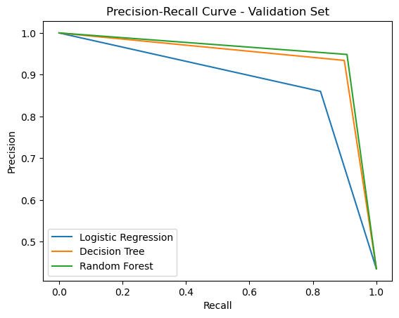

```python
# Create a dictionary to store the predictions for each model
y_pred_val_dict = {
    'Logistic Regression': y_pred_val_lr,
    'Decision Tree': y_pred_val_dt,
    'Random Forest': y_pred_val_rf
}

# Plot Precision-Recall curves for each model
for index, row in validation_results_df.iterrows():
    model_name = row['Model']
    precision, recall, _ = precision_recall_curve(y_val, y_pred_val_dict[model_name])

    # Plot Precision-Recall curve
    plt.plot(recall, precision, label=model_name)

# Customize the plot
plt.xlabel('Recall')
plt.ylabel('Precision')
plt.title('Precision-Recall Curve - Validation Set')
plt.legend()
plt.show()
```

The precision-recall curve shows the tradeoff between precision and recall for different threshold. A high area under the curve represents both high recall and high precision, where high precision relates to a low false positive rate, and high recall relates to a low false negative rate. Above graph has both high recall and high precision.

### K-FOLD Crossvalidation on Random forest algorithm

Cross-validation is a statistical method used to estimate the skill of machine learning models.

It is commonly used in applied machine learning to compare and select a model for a given predictive modeling problem because it is easy to understand, easy to implement, and results in skill estimates that generally have a lower bias than other methods.

K-fold is a type of crossvalidation technique

**K-fold**  
The procedure has a single parameter called k that refers to the number of groups that a given data sample is to be split into. As such, the procedure is often called k-fold cross-validation. When a specific value for k is chosen, it may be used in place of k in the reference to the model, such as k=10 becoming 10-fold cross-validation.

```python
from sklearn.model_selection import cross_val_score, KFold

num_folds = 5
kf = KFold(n_splits=num_folds, shuffle=True, random_state=42)

# Perform cross-validation
cv_scores_lr = cross_val_score(lr, X_train, y_train, cv=kf, scoring='accuracy')
cv_scores_dt = cross_val_score(dt, X_train, y_train, cv=kf, scoring='accuracy')
cv_scores_rf = cross_val_score(rf, X_train, y_train, cv=kf, scoring='accuracy')

# Print the cross-validation scores
print("LOGISTIC REGRESSION")
print("K-Fold Cross-validation scores:", cv_scores_lr)
print("Mean accuracy:", np.mean(cv_scores_lr))
print("="*33)

print("DECISION TREE CLASSIFIER")
print("K-Fold Cross-validation scores:", cv_scores_dt)
print("Mean accuracy:", np.mean(cv_scores_dt))
print("="*33)

print("RANDOM FOREST CLASSIFIER")
print("K-Fold Cross-validation scores:", cv_scores_rf)
print("Mean accuracy:", np.mean(cv_scores_rf))
```

```
LOGISTIC REGRESSION
K-Fold Cross-validation scores: [0.86507122 0.86378801 0.86629026 0.86698749 0.86698749]
Mean accuracy: 0.8658248938146533
=================================
DECISION TREE CLASSIFIER
K-Fold Cross-validation scores: [0.9272424  0.93000128 0.9269216  0.92390119 0.92755855]
Mean accuracy: 0.9271250026913502
=================================
RANDOM FOREST CLASSIFIER
K-Fold Cross-validation scores: [0.93725138 0.93904786 0.94026691 0.93827398 0.93974976]
Mean accuracy: 0.9389179779769122
```

### Comparision of accuracy scores of different algorithms used

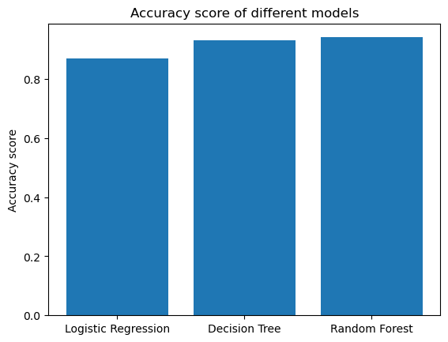

```python
plt.bar(results_df['Model'], results_df['Accuracy'])
plt.title('Accuracy score of different models')
plt.ylabel("Accuracy score")
plt.show()
```

Above is comparison of acuracy score on test data for supervised learning algorithm used, that are Logistic regression, Decision tree classifier, Random forest classifier.

1. Logistic regression - 86%
2. Decision tree classifier - 93%
3. Random Forest Classifier - 94%

Accuracy scores of Random forest and Decision tree are almost same, and better than accuracy socre of logistic regression.

According to me best algorithm for given dataset is Random forest Classifier because it gave best accuracy, precision, recall and f1 scores compared to other two algorithms. Also RFC if applied with best parameters it can become more accurate.

## CONCLUSION

[figure not shown]

**Validation Set**  
Similar robust performance is observed on the validation set, affirming the models' generalization capability:

[figure not shown]

## FURTHER ANALYSIS

**Address Outliers**  
Investigate and address outliers in Flight Distance', 'Departure Delay in Minutes', and 'Arrival Delay in Minutes.

**Explore Alternative Models**  
Consider exploring alternative machine learning models to enhance predictive performance.